# Projeto ANUBIS — Notas Analíticas Preliminares

- Mostrar o código
- Esconder o código
- Ver o código fonte

Construção da Base Populacional e Decisões Metodológicas

R

Ciência de dados

Visualização de dados

Artigo

Autor

Majory Melo

Data de Publicação

02 de abril de 2026

**Sobre este documento**

Este arquivo registra observações e análises preliminares do **Projeto ANUBIS** — estudo de séries temporais de suicídio no Brasil (2000–2022). O objetivo é documentar decisões metodológicas e fornecer evidências para a redação do manuscrito.

Repositório: github.com/EnigmaMajoris/anubis  
Project board: [github.com/users/EnigmaMajoris/projects/2](https://github.com/users/EnigmaMajoris/projects/2/views/2)

# 1 Visão geral da estratégia populacional

A construção da base populacional seguiu uma estratégia em dois níveis distintos:

**Nível 1 — Totais populacionais anuais:** obtidos integralmente de fontes observadas, sem imputação. Para os anos censitários e de contagem (2000, 2007, 2010 e 2022), os totais provêm diretamente dos levantamentos do IBGE. Para os demais anos (2001–2006 e 2008–2021), utilizam-se as estimativas intercensitárias da Tabela SIDRA 6579.

**Nível 2 — Desagregação por sexo nos anos intermediários:** as proporções masculina e feminina foram interpoladas a partir de quatro âncoras observadas (2000, 2007, 2010 e 2022) e aplicadas sobre os totais do Nível 1.

A principal decisão metodológica desta etapa — a escolha do método de interpolação das proporções por sexo — é documentada em detalhe na Seção 3.

## 1.1 Fontes utilizadas

Tabela 1: Fontes populacionais utilizadas na construção da série 2000–2022

| Fonte | Tabela SIDRA | Cobertura | Variáveis |
| --- | --- | --- | --- |
| Censo Demográfico 2000 | Tab. 200 | Nacional por macrorregião | Total, homens, mulheres |
| Contagem da População 2007 | Tab. 794 | Municípios ≤ 170 mil hab. | Total, homens, mulheres |
| Censo Demográfico 2010 | Tab. 200 | Nacional por macrorregião | Total, homens, mulheres |
| Estimativas anuais 2001–2021 | Tab. 6579 | Nacional por macrorregião | Total |
| Censo Demográfico 2022 | Tab. 9514 | Nacional por macrorregião | Total, homens, mulheres |

# 2 A Contagem da População de 2007

## 2.1 Por que o total de 2007 diverge dos anos adjacentes?

Ao visualizar a série do Brasil, o ano de 2007 apresenta total de **108.765.037 pessoas** — muito abaixo dos ~186 milhões de 2006 e ~189 milhões de 2008. Esse valor não é erro de processamento. Reflete a natureza da operação censitária.

**Explicação oficial — IBGE (2007)**

A Contagem da População de 2007 não cobriu todos os municípios brasileiros. Por razões orçamentárias, o levantamento de campo foi restrito aos **municípios com até 170 mil habitantes**, universo que na época correspondia a 5.435 dos 5.564 municípios existentes. Para os **129 municípios excluídos** — todos de grande porte, predominantemente metropolitanos — o IBGE produziu estimativas separadas com metodologia própria.

**Fonte:** IBGE. *Contagem da População 2007: primeiros resultados*. Rio de Janeiro: IBGE, 2007. Disponível em: biblioteca.ibge.gov.br/visualizacao/livros/liv37666.pdf

**Fonte complementar:** IBGE. *Metodologia do Censo Demográfico 2010*. Rio de Janeiro: IBGE, 2013. p. 28–30. (Série Relatórios Metodológicos, v. 41). Disponível em: biblioteca.ibge.gov.br/visualizacao/livros/liv52675.pdf

## 2.2 Papel da Contagem 2007 neste projeto

A Contagem de 2007 é utilizada **exclusivamente como âncora para interpolação das proporções por sexo** — não dos totais populacionais. Essa distinção é fundamental: o que nos interessa de 2007 é a relação observada entre homens e mulheres, não o total absoluto recenseado.

**Código**

```r
ancoras |>
  filter(local == "Brasil") |>
  mutate(
    fonte = case_when(
      ano == 2000 ~ "Censo 2000",
      ano == 2007 ~ "Contagem 2007*",
      ano == 2010 ~ "Censo 2010",
      ano == 2022 ~ "Censo 2022"
    ),
    `% Masculino` = round(prop_masc * 100, 3),
    `% Feminino`  = round(prop_fem  * 100, 3),
    `Total`       = format(populacao_total, big.mark = ".", decimal.mark = ",")
  ) |>
  select(Ano = ano, Fonte = fonte, `Total`, `% Masculino`, `% Feminino`) |>
  kable(align = c("c","l","r","c","c")) |>
  kable_styling(full_width = FALSE, bootstrap_options = c("striped","hover")) |>
  footnote(
    symbol = "Cobertura parcial: municípios com ≤ 170 mil habitantes (IBGE, 2007).",
    footnote_as_chunk = TRUE
  )
```

Tabela 2: Proporções por sexo nas quatro âncoras censitárias — Brasil

| Ano | Fonte | Total | % Masculino | % Feminino |
| --- | --- | --- | --- | --- |
| 2000 | Censo 2000 | 169.872.856 | 49.215 | 50.785 |
| 2007 | Contagem 2007* | 108.765.037 | 49.542 | 49.728 |
| 2010 | Censo 2010 | 190.755.799 | 48.967 | 51.033 |
| 2022 | Censo 2022 | 203.080.756 | 48.519 | 51.481 |

* Cobertura parcial: municípios com ≤ 170 mil habitantes (IBGE, 2007).

## 2.3 Implicação metodológica: viés de seleção nas proporções de 2007

A exclusão dos 129 municípios grandes da Contagem levanta uma questão legítima: **as proporções por sexo calculadas a partir da amostra coberta são representativas da população total?**

Municípios de grande porte e metropolitanos tendem a concentrar **maior proporção feminina**, em razão dos padrões históricos de migração interna brasileira — onde mulheres migram em maior proporção para centros urbanos em busca de trabalho doméstico e serviços [@simoes2016]. A exclusão desses municípios poderia, em tese, superestimar a proporção masculina na Contagem.

# 3 Comparação de métodos de interpolação

## 3.1 Contexto da decisão

Para os anos intermediários entre as âncoras censitárias, as proporções por sexo foram estimadas por interpolação. Dois métodos foram avaliados em paralelo sobre as mesmas âncoras e os mesmos dados:

- **Spline cúbica natural** (`zoo::na.spline`): ajusta polinômios de grau 3 entre os pontos de ancoragem, minimizando a curvatura total da série. É o método de interpolação mais suave e frequentemente adotado em séries demográficas [@hyndman2018forecasting].
- **Interpolação linear por partes** (`zoo::na.approx`): conecta as âncoras por segmentos de reta, sem curvatura adicional. É o método mais conservador e matematicamente mais simples.

A escolha entre os métodos foi feita com base em critérios objetivos, documentados a seguir.

## 3.2 Envelope demográfico das âncoras

O critério principal de avaliação foi a **permanência dentro do envelope demográfico** — faixa definida pelos valores mínimo e máximo de proporção masculina observados nas quatro âncoras, acrescidos de margem de tolerância de 0,5 ponto percentual por região.

**Código**

```r
envelope |>
  mutate(across(where(is.numeric), ~ round(.x, 3))) |>
  rename(
    Região             = local,
    `Mín observado`   = prop_masc_min_obs,
    `Máx observado`   = prop_masc_max_obs,
    `Limite inferior` = prop_masc_min,
    `Limite superior` = prop_masc_max
  ) |>
  kable(align = c("l","c","c","c","c")) |>
  kable_styling(full_width = FALSE, bootstrap_options = c("striped","hover")) |>
  add_header_above(c(" " = 1,
                     "Âncoras observadas" = 2,
                     "Envelope (± 0,5 p.p.)" = 2))
```

| Região | Âncoras observadas Mín observado | Âncoras observadas Máx observado | Envelope (± 0,5 p.p.) Limite inferior | Envelope (± 0,5 p.p.) Limite superior |
| --- | --- | --- | --- | --- |
| Brasil | 0.485 | 0.495 | 0.480 | 0.500 |
| Centro-Oeste | 0.492 | 0.502 | 0.487 | 0.507 |
| Nordeste | 0.483 | 0.491 | 0.478 | 0.496 |
| Norte | 0.499 | 0.506 | 0.494 | 0.511 |
| Sudeste | 0.482 | 0.496 | 0.477 | 0.501 |
| Sul | 0.487 | 0.495 | 0.482 | 0.500 |

## 3.3 Figura 1 — Trajetórias comparadas por região

**Código**

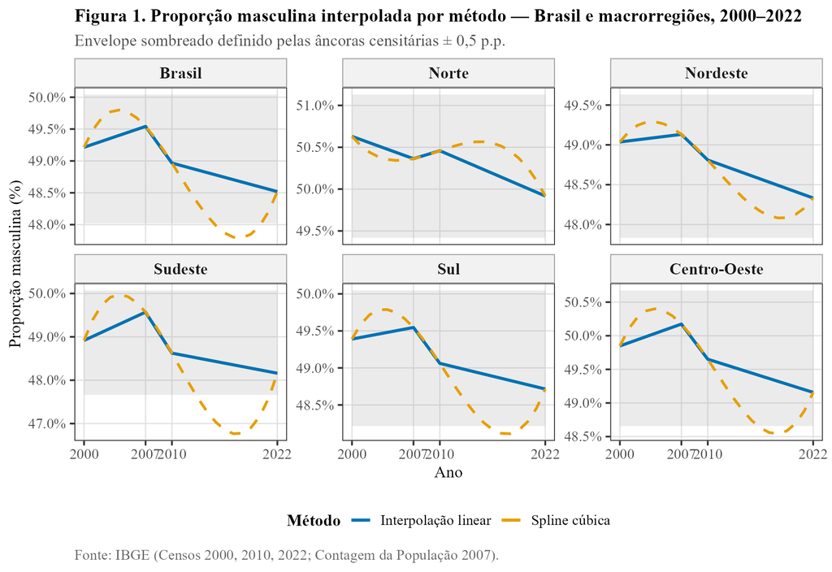

```r
knitr::include_graphics(
  file.path(caminho_figuras, "fig01_proporcoes_spline_vs_linear.png")
)
```

A spline cúbica produz trajetórias claramente não-plausíveis em quatro das seis regiões: após atingir um pico artificial em torno de 2005 (efeito da curvatura induzida pelo intervalo curto de apenas três anos entre as âncoras de 2007 e 2010), a série despenca acentuadamente até 2017–2018, ultrapassando os limites inferiores do envelope. A interpolação linear, por contraste, acompanha a tendência geral de suave declínio na proporção masculina sem oscilações espúrias.

## 3.4 Diagnóstico quantitativo da spline

**Código**

```r
diag_spline |>
  mutate(
    desvio_max_pp = round(desvio_max_pp, 4),
    ano_pior      = ifelse(is.na(ano_pior), "—", as.character(ano_pior))
  ) |>
  rename(
    Região                      = local,
    `Anos fora do envelope (n)` = n_anos_fora,
    `Desvio máx. (p.p.)`       = desvio_max_pp,
    `Ano do maior desvio`       = ano_pior
  ) |>
  kable(align = c("l","c","c","c")) |>
  kable_styling(full_width = FALSE, bootstrap_options = c("striped","hover")) |>
  row_spec(which(diag_spline$n_anos_fora > 0), background = "#FFF3CD")
```

Tabela 4: Diagnóstico da spline cúbica por macrorregião — anos interpolados

| Região | Anos fora do envelope (n) | Desvio máx. (p.p.) | Ano do maior desvio |
| --- | --- | --- | --- |
| Sudeste | 9 | 0.8952 | 2017 |
| Brasil | 6 | 0.2255 | 2018 |
| Centro-Oeste | 4 | 0.1146 | 2018 |
| Sul | 4 | 0.1039 | 2018 |
| Nordeste | 0 | 0.0000 | — |
| Norte | 0 | 0.0000 | — |

**Concentração do problema no Sudeste**

A região Sudeste concentrou **9 dos 23 casos** de extrapolação, com desvio máximo de **0.895 p.p.** em 2017. Essa concentração não é aleatória: o Sudeste possui as maiores metrópoles do país — exatamente os municípios excluídos da Contagem 2007 — o que amplia o impacto do viés de seleção daquela fonte na âncora de 2007 e, consequentemente, na curvatura da spline naquele segmento.

## 3.5 Figura 2 — Overshoot da spline por região

**Código**

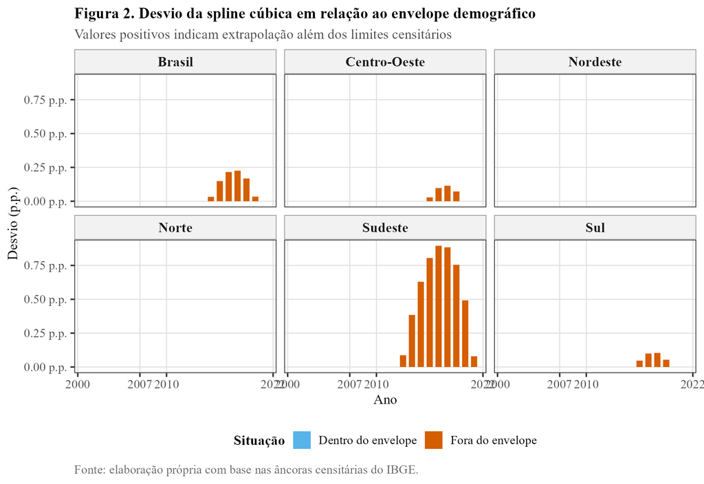

Figura 2: Desvio da spline cúbica em relação ao envelope demográfico — anos interpolados. Barras laranjas: casos de extrapolação além do limite do envelope.

```r
knitr::include_graphics(
  file.path(caminho_figuras, "fig02_overshoot_spline.png")
)
```

A figura confirma que o overshoot é um fenômeno **concentrado temporalmente** (2012–2021) e **regionalmente** (Sudeste e, em menor grau, Brasil agregado), não distribuído aleatoriamente ao longo da série. Esse padrão é consistente com a explicação geométrica: o intervalo de apenas três anos entre as âncoras de 2007 e 2010 força a spline a fazer uma inflexão abrupta, com propagação de curvatura espúria para os anos subsequentes.

## 3.6 Figura 3 — Diferença absoluta entre métodos

**Código**

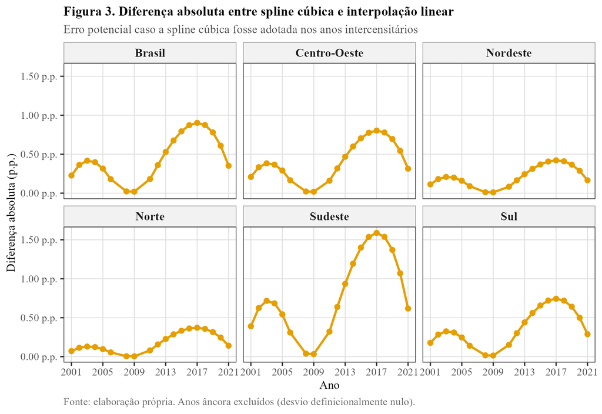

Figura 3: Diferença absoluta entre spline cúbica e interpolação linear (p.p.) — anos interpolados. Representa o erro que seria introduzido nas proporções caso a spline fosse adotada.

```r
knitr::include_graphics(
  file.path(caminho_figuras, "fig03_diferenca_absoluta_metodos.png")
)
```

**Código**

```r
comp_metodos |>
  mutate(
    dif_media_pp = round(dif_media_pp, 3),
    dif_max_pp   = round(dif_max_pp, 3)
  ) |>
  rename(
    Região                        = local,
    `Dif. média (p.p.)`          = dif_media_pp,
    `Dif. máx. (p.p.)`           = dif_max_pp,
    `Ano da maior diferença`      = ano_max_dif
  ) |>
  kable(align = c("l","c","c","c")) |>
  kable_styling(full_width = FALSE, bootstrap_options = c("striped","hover")) |>
  row_spec(1, bold = TRUE, background = "#F8D7DA")
```

Tabela 5: Diferença entre spline cúbica e interpolação linear por macrorregião

| Região | Dif. média (p.p.) | Dif. máx. (p.p.) | Ano da maior diferença |
| --- | --- | --- | --- |
| Sudeste | 0.818 | 1.588 | 2017 |
| Brasil | 0.467 | 0.903 | 2017 |
| Centro-Oeste | 0.418 | 0.803 | 2017 |
| Sul | 0.381 | 0.743 | 2017 |
| Nordeste | 0.221 | 0.422 | 2017 |
| Norte | 0.183 | 0.371 | 2017 |

A maior divergência entre os métodos atingiu **1.588 p.p.** na região **Sudeste** em **2017**. Em termos populacionais, esse desvio corresponderia a um erro de aproximadamente **1.381.024 pessoas** na desagregação por sexo naquele ano — magnitude relevante para denominadores de taxas de mortalidade em estudos de séries temporais.

## 3.7 Quadro comparativo final

**Código**

```r
tibble(
  Critério = c(
    "Anos/região fora do envelope demográfico",
    "Inflexões não-monotônicas detectadas",
    "Desvio máximo do envelope (p.p.)",
    "Maior divergência entre métodos (p.p.)",
    "Região/ano crítico",
    "Garantia de monotonia por segmento",
    "Método adotado para a série final"
  ),
  `Spline cúbica` = c(
    glue("{n_fora_spline} casos"),
    "12 inflexões",
    glue("{round(max(diag_spline$desvio_max_pp),3)}"),
    glue("{round(dif_max_global,3)}"),
    glue("{regiao_max_dif} / {ano_max_dif}"),
    "❌  Não",
    "❌  Não"
  ),
  `Interpolação linear` = c(
    "0 casos",
    "0 (por definição)",
    "—",
    "0 (referência)",
    "—",
    "✅  Sim",
    "✅  Sim"
  )
) |>
  kable(align = c("l","c","c")) |>
  kable_styling(full_width = TRUE, bootstrap_options = c("striped","hover")) |>
  row_spec(7, bold = TRUE, background = "#D4EDDA") |>
  column_spec(1, width = "50%")
```

Tabela 6: Comparação entre spline cúbica e interpolação linear — critérios de seleção do método

| Critério | Spline cúbica | Interpolação linear |
| --- | --- | --- |
| Anos/região fora do envelope demográfico | 23 casos | 0 casos |
| Inflexões não-monotônicas detectadas | 12 inflexões | 0 (por definição) |
| Desvio máximo do envelope (p.p.) | 0.895 | — |
| Maior divergência entre métodos (p.p.) | 1.588 | 0 (referência) |
| Região/ano crítico | Sudeste / 2017 | — |
| Garantia de monotonia por segmento | ❌ Não \| | ✅ Sim \| |
| Método adotado para a série final | ❌ Não \| | ✅ Sim \| |

**Justificativa metodológica — rascunho para o manuscrito**

A desagregação da população por sexo nos anos intermediários foi realizada por **interpolação linear por partes** das proporções masculina e feminina calculadas nas quatro âncoras censitárias observadas (Censos de 2000, 2010 e 2022; Contagem da População de 2007). Dois métodos foram avaliados em paralelo — spline cúbica natural e interpolação linear — sobre as mesmas âncoras e o mesmo período.

A spline cúbica produziu extrapolações fora do envelope demográfico plausível em **23 combinações** ano-região (de 114 avaliadas), com desvio máximo de **0.895 p.p.** na região Sudeste em 2017, e apresentou **12 inflexões não-monotônicas**. O fenômeno foi atribuído ao intervalo de apenas três anos entre as âncoras de 2007 e 2010, que induziu curvatura excessiva com propagação de artefato para os anos subsequentes. A maior divergência entre os dois métodos atingiu **1.588 p.p.** no Sudeste em 2017.

A interpolação linear permaneceu integralmente dentro do envelope em todas as combinações ano-região avaliadas e, por ser monotônica em cada segmento por definição matemática, não gerou inflexões espúrias. Em face desses resultados, a interpolação linear foi adotada como método para a série final.

# 4 Análise de sensibilidade — âncora de 2007

**Código**

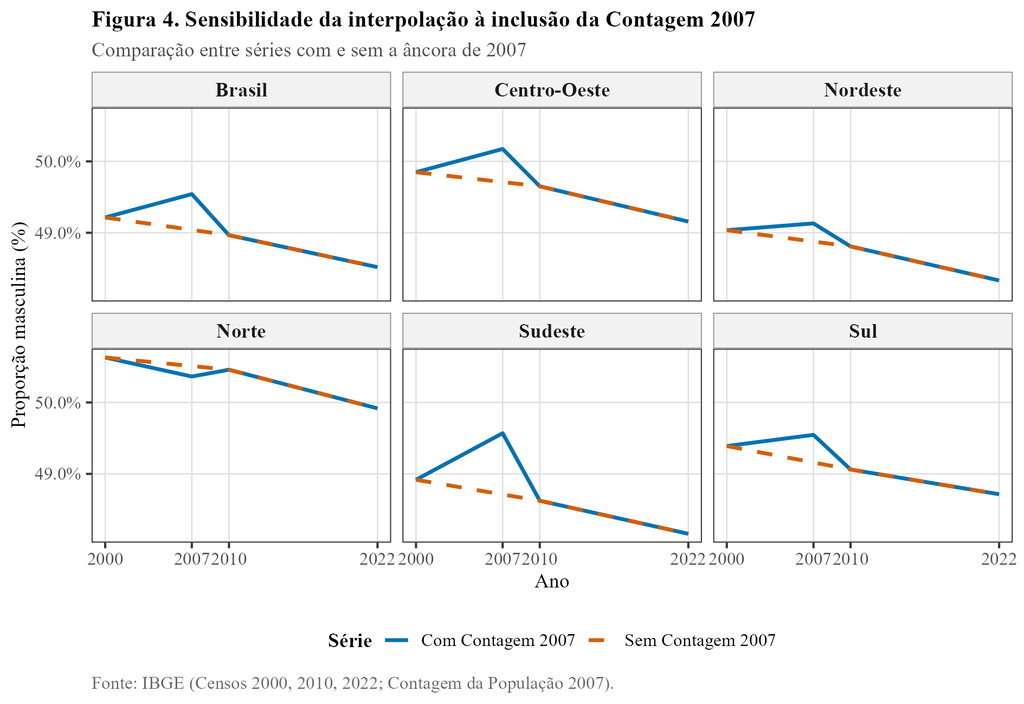

Figura 4: Análise de sensibilidade — impacto de incluir a Contagem 2007 como âncora. Comparação entre interpolação linear com e sem a âncora de 2007.

```r
knitr::include_graphics(
  file.path(caminho_figuras, "fig04_sensibilidade_2007.png")
)
```

**Nota para a banca**

A pergunta previsível é: *“se a Contagem 2007 tem cobertura parcial, por que usá-la como âncora?”*

A resposta é que **a alternativa — não usar a Contagem e interpolar entre 2000 e 2010 — também tem limitações**, e mais graves: produz uma série baseada em um único segmento de 10 anos sem referência intermediária observada. A Contagem 2007, apesar da cobertura parcial, é a única fonte de campo disponível para o período intercensitário, e suas proporções por sexo são biologicamente plausíveis e coerentes com a tendência entre 2000 e 2010. A análise de sensibilidade documenta formalmente o impacto de incluí-la, permitindo que o leitor avalie a robustez das escolhas.

# 5 Proporções observadas nas âncoras censitárias

**Código**

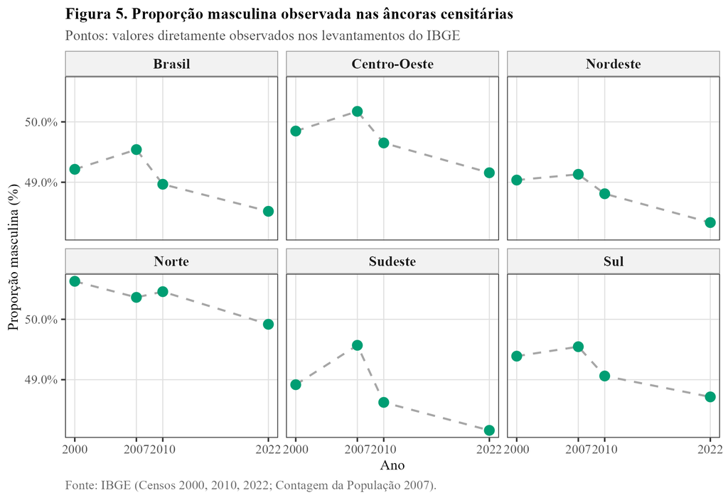

```r
knitr::include_graphics(
  file.path(caminho_figuras, "fig05_ancoras_censitarias.png")
)
```

**Código**

```r
ancoras |>
  mutate(
    fonte = case_when(
      ano == 2000 ~ "Censo 2000",
      ano == 2007 ~ "Contagem 2007*",
      ano == 2010 ~ "Censo 2010",
      ano == 2022 ~ "Censo 2022"
    ),
    `% Masculino` = round(prop_masc * 100, 3)
  ) |>
  select(Região = local, Ano = ano, Fonte = fonte, `% Masculino`) |>
  pivot_wider(
    names_from  = c(Ano, Fonte),
    values_from = `% Masculino`,
    names_glue  = "{Ano}\n{Fonte}"
  ) |>
  kable(align = "lcccc") |>
  kable_styling(full_width = FALSE, bootstrap_options = c("striped","hover")) |>
  footnote(
    symbol = "Cobertura parcial: municípios com ≤ 170 mil habitantes.",
    footnote_as_chunk = TRUE
  )
```

Tabela 7: Proporções masculinas observadas nas quatro âncoras censitárias — todas as regiões

[output not shown]

* Cobertura parcial: municípios com ≤ 170 mil habitantes.

# 6 Série populacional final

**Código**

```r
pop_final |>
  filter(local == "Brasil") |>
  mutate(
    prop_masc = round(pop_masculino / populacao_total * 100, 3),
    across(c(populacao_total, pop_masculino, pop_feminino),
           ~ format(.x, big.mark = ".", decimal.mark = ","))
  ) |>
  select(
    Ano           = ano,
    `Total`       = populacao_total,
    `Masculino`   = pop_masculino,
    `Feminino`    = pop_feminino,
    `% Masc.`     = prop_masc
  ) |>
  kable(align = c("c","r","r","r","c")) |>
  kable_styling(full_width = FALSE, bootstrap_options = c("striped","hover")) |>
  row_spec(which(pop_final |> filter(local=="Brasil") |> pull(ano) == 2007),
           background = "#FFF3CD") |>
  footnote(
    general = "Linha em amarelo: ano da Contagem da População (total observado na operação censitária, não estimativa da população total do Brasil).",
    footnote_as_chunk = TRUE
  )
```

Tabela 8: Série populacional final — Brasil, 2000–2022 (interpolação linear adotada)

| Ano | Total | Masculino | Feminino | % Masc. |
| --- | --- | --- | --- | --- |
| 2000 | 169.872.856 | 83.602.317 | 86.270.539 | 49.215 |
| 2001 | 172.385.826 | 84.919.564 | 87.286.368 | 49.261 |
| 2002 | 174.632.960 | 86.108.080 | 88.160.403 | 49.308 |
| 2003 | 176.871.437 | 87.294.422 | 89.023.292 | 49.355 |
| 2004 | 181.569.056 | 89.697.705 | 91.113.445 | 49.401 |
| 2005 | 184.184.264 | 91.075.663 | 92.147.573 | 49.448 |
| 2006 | 186.770.562 | 92.441.754 | 93.159.380 | 49.495 |
| 2007 | 108.765.037 | 53.883.849 | 54.086.675 | 49.542 |
| 2008 | 189.605.006 | 93.569.958 | 95.111.689 | 49.350 |
| 2009 | 191.480.630 | 94.128.747 | 96.885.637 | 49.158 |
| 2010 | 190.755.799 | 93.406.990 | 97.348.809 | 48.967 |
| 2011 | 192.379.287 | 94.130.147 | 98.249.140 | 48.929 |
| 2012 | 193.904.015 | 94.803.806 | 99.100.209 | 48.892 |
| 2013 | 201.032.714 | 98.214.135 | 102.818.579 | 48.855 |
| 2014 | 202.768.562 | 98.986.489 | 103.782.073 | 48.817 |
| 2015 | 204.450.049 | 99.731.029 | 104.719.020 | 48.780 |
| 2016 | 206.081.432 | 100.449.892 | 105.631.540 | 48.743 |
| 2017 | 207.660.929 | 101.142.266 | 106.518.663 | 48.705 |
| 2018 | 208.494.900 | 101.470.627 | 107.024.273 | 48.668 |
| 2019 | 210.147.125 | 102.196.288 | 107.950.837 | 48.631 |
| 2020 | 211.755.692 | 102.899.502 | 108.856.190 | 48.593 |
| 2021 | 213.317.639 | 103.578.877 | 109.738.762 | 48.556 |
| 2022 | 203.080.756 | 98.532.431 | 104.548.325 | 48.519 |

Note: Linha em amarelo: ano da Contagem da População (total observado na operação censitária, não estimativa da população total do Brasil).

# 7 Referências bibliográficas e fontes

**Fontes institucionais:**

- IBGE. *Contagem da População 2007*. Rio de Janeiro: IBGE, 2007. biblioteca.ibge.gov.br/visualizacao/livros/liv37666.pdf
- IBGE. *Estimativas da população residente nos municípios brasileiros — Tabela SIDRA 6579*. Disponível em: sidra.ibge.gov.br/tabela/6579
- IBGE. *Projeções da população do Brasil e das Unidades da Federação — Revisão 2018 — Tabela SIDRA 7358*. Disponível em: sidra.ibge.gov.br/tabela/7358
- IBGE. *Censo Demográfico 2022 — Tabela SIDRA 9514*. Disponível em: sidra.ibge.gov.br/tabela/9514
- IBGE. *Sinopse do Censo Demográfico 2010 — Tabela SIDRA 200*. Disponível em: sidra.ibge.gov.br/tabela/200
- IBGE. *Contagem da População 2007 — Tabela SIDRA 794*. Disponível em: sidra.ibge.gov.br/tabela/794

**Referências metodológicas:**

- HYNDMAN, R. J.; ATHANASOPOULOS, G. *Forecasting: principles and practice*.
  3. ed. Melbourne: OTexts, 2021. Disponível em: otexts.com/fpp3
- SIMÕES, C. C. S. *Relações entre as alterações históricas na dinâmica demográfica brasileira e os impactos decorrentes do processo de envelhecimento da população*. Rio de Janeiro: IBGE, 2016. biblioteca.ibge.gov.br/visualizacao/livros/liv98579.pdf
- IBGE. *Projeções da população: Brasil e Unidades da Federação — revisão 2018*. Rio de Janeiro: IBGE, 2018. (Série Relatórios Metodológicos, v. 40). biblioteca.ibge.gov.br/visualizacao/livros/liv101597.pdf

**Informações da sessão R**

**Código**